# Metropolis Markov Chain Monte Carlo Simulations in R

Content Creator: Jeremy Haynes

Content Editors: Billy Mitchell

2024-07-24

# Conceptual Background

[video not shown]

# Install/Load Packages

```r
knitr::opts_chunk$set(echo = T, warning = F, message = F, fig.align = "center")

# -------------------------------------
# INSTALL THESE IF YOU NEED THEM
# install.packages("tidyverse")
# install.packages("gganimate")
# install.packages("here")
# install.packages("extraDistr")

# -------------------------------------
# LOAD PACKAGES
library(tidyverse)
library(gganimate)
library(here)
library(extraDistr)
```

# Load Data

For the sake of time, I will not be walking through how I simulated the data for the workshop; however, I highly recommend taking the time to [go through the code (demand_data_simulation.R)](https://github.com/TU-Coding-Outreach-Group/cog_summer_workshops_2024/blob/main/metro_mcmc_in_r/demand_data_simulation.R). Knowing how to simulate data that is relevant to your work is an excellent way to truly understand the characteristics of the data that you work with. In addition, simulating data for a model forces you to think more deeply about the assumptions and constraints you are imposing with your model.

## Load Data

```r
demand_data = readRDS(here("metro_mcmc_in_r", "demand_data.RDS"))
```

## Inspect Data

The dataset contains 4 variables: $id$, $year$ (years using fentanyl), $sex$ (female = 0, male = 1), and $log\_elasticity$ (how sensitive consumption/demand is to changes in price). These data are already formatted for our purposes, but it is worth inspecting the data.

```r
# QUICK PEAK
head(demand_data)
```

|  | id | year | sex | log_elasticity |
| --- | --- | --- | --- | --- |
| 1 | 1 | 9.52 | 1 | -6.967613 |
| 2 | 2 | 6.15 | 0 | -5.438124 |
| 3 | 3 | 0.21 | 0 | -3.279293 |
| 4 | 4 | 17.63 | 0 | -10.000714 |
| 5 | 5 | 2.26 | 0 | -3.519041 |
| 6 | 6 | 15.83 | 1 | -7.212887 |

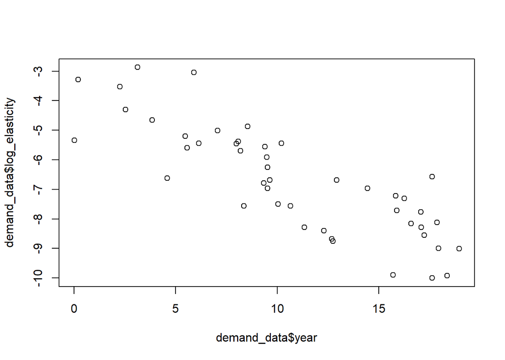

```r
# SCATTERPLOT
plot(demand_data$year, demand_data$log_elasticity)
```

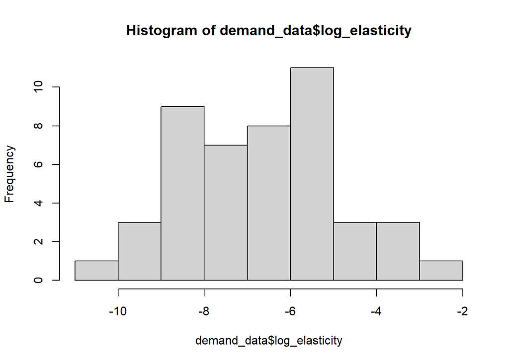

```r
# HISTOGRAM
hist(demand_data$log_elasticity)
```

```r
# SUMMARY STATISTICS
summary(demand_data)
```

```
##        id             year            sex         log_elasticity
##  Min.   : 1.00   Min.   : 0.02   Min.   :0.0000   Min.   :-10.001
##  1st Qu.:12.25   1st Qu.: 7.30   1st Qu.:0.0000   1st Qu.: -8.144
##  Median :23.50   Median : 9.84   Median :0.0000   Median : -6.738
##  Mean   :23.50   Mean   :10.70   Mean   :0.4783   Mean   : -6.690
##  3rd Qu.:34.75   3rd Qu.:15.88   3rd Qu.:1.0000   3rd Qu.: -5.437
##  Max.   :46.00   Max.   :18.95   Max.   :1.0000   Max.   : -2.869
```

```r
# CLASSES OF VARIABLES
sapply(demand_data, class)
```

```
##             id           year            sex log_elasticity
##      "integer"      "numeric"      "integer"      "numeric"
```

# Specify Model

## The Model

Before programming the MCMC, we need to specify each part of our model. To begin, let’s specify the model we assume generated the data (i.e., the regression model):
$$y_i = \beta_0
+ \beta_1 x_i + \epsilon_i$$

where

$$\epsilon_i \sim
Normal(0,\sigma^2)$$

An equivalent way to write this is to specify the whole model as the following:

$$y_i \sim Normal(\beta_0 + \beta_1
x_i,\sigma^2)$$
Using this parameterization will make things easier to understand later on.

Overall, we have three parameters to estimate: $\beta_0$, $\beta_1$, and $\sigma^2$. Because many of the functions we’ll be using (e.g., $dnorm()$) take standard deviations as their input, we will estimate $\sigma$. Therefore, our goal is to use MCMC to estimate the posterior distributions of $\beta_0$, $\beta_1$, and $\sigma$, given the observed data $y$:
$$P(\beta_0, \beta_1,\sigma|y_i)$$

We’ll do this with Bayes rule:
$$P(\beta_0, \beta_1,\sigma|) = \frac{P(y|\beta_0,
\beta_1,\sigma) \cdot P(\beta_0) P(\beta_1)
P(\sigma)}{P(y)}$$

Because we’re using MCMC to sample from the posterior distribution, we do not need to estimate the marginal distribution (i.e., the denominator): $P(y)$. Thus,
$$P(\beta_0, \beta_1,\sigma|y) \propto P(y|\beta_0,
\beta_1, \sigma) \cdot P(\beta_0) P(\beta_1) P(\sigma)$$
Where we have the posterior distribution on the left as proportional to the joint distribution of the prior and the likelihood on the right. Now that we’ve specified our model, we need to build each piece.

## The Likelihood

Here, our goal is to calculate the probability of the data, given a set of parameter values:
$$P(y|\beta_0,
\beta_1, \sigma)$$

We’ll do this by calculating the joint probability of all the data assuming the data were generated from a given set of parameters.
$$= P(y_1|\beta_0, \beta_1, \sigma) \times
P(y_2|\beta_0, \beta_1, \sigma) \times... P(y_N|\beta_0, \beta_1,
\sigma)$$

We do this in a surprisingly simple way. Remember what our model is:

$$y_i \sim Normal(\beta_0 + \beta_1 x_i,
\sigma)$$

R has built-in functions to calculate the probability of a given value according to a pre-specified mean and standard deviation: $dnorm(x, mean = 0, sd = 1, log = FALSE)$. (technically, these are probability densities because we’re working with continuous variables) Remember that we want to do this in log-space, so in the function, we’ll specify $log = TRUE$. Because of this, we’ll be adding the log-likelihoods together instead of multiplying them: $Log\big[P(y_1|\beta_0, \beta_1, \sigma)\big] + Log\big[P(y_2|\beta_0, \beta_1, \sigma)\big] +... Log\big[P(y_N|\beta_0, \beta_1, \sigma)\big]$. We will calculate the likelihood for each iteration of the MCMC; therefore, to simplify things, we’ll make a function to do this. The inputs for this function will be the data and parameter values; the output will be the joint probability of the data given the parameters (i.e., it’ll just be a single probability).

```r
calculate_likelihood = function(y, x, B0, B1, sigma){
  # calculate log likelihood of our data, given the model
  log_likelihood =
    # first, we'll calculate the log-likelihood of each observation
    dnorm(y,         # data we want probabilities for
          B0 + B1*x, # current parameter for the mean
          sigma,     # current parameter for sigma
          log = TRUE # log probability density to avoid Pbxs with small numbers problems
    ) %>%
    # next, we'll sum those log-likelihoods to get our joint probability
    sum()
  # return that stuff
  return(log_likelihood)
}
```

## Priors

Here, we want to calculate the prior probability of a given parameter value. That is, the probability of a given parameter value INDEPENDENT OF THE DATA.
$$P(\beta_0), P(\beta_1),
P(\sigma)$$

We’re going to specify these priors separately for each parameter. Let’s set very weakly informative priors:
$$\beta_0 \sim Normal(0, 50)$$

$$\beta_1 \sim Normal(0, 50)$$

$$\sigma \sim Half-Cauchy(0, 50)$$
Why am I using a half-Cauchy distribution for the prior on $\sigma$?… I know that sigma HAS TO BE POSITIVE (standard deviations cannot be negative). Thus, I’m specifying the half-Cauchy so that only positive values are plausible.

It’s wise to plot your priors to get a sense of what you’re assuming with them:

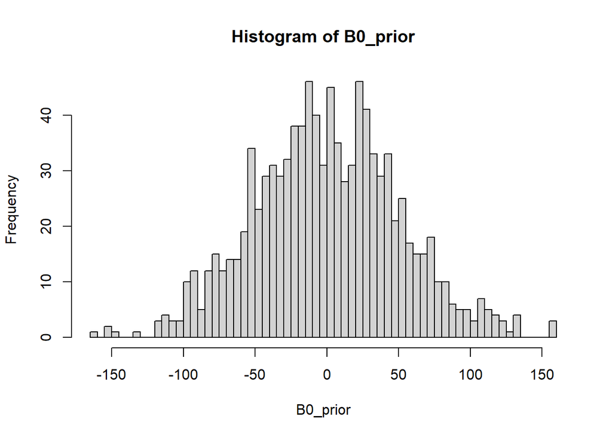

```r
# INTERCEPT
B0_prior = rnorm(1000, 0, 50) # draw 1000 random values from our prior
hist(B0_prior, breaks = 50)   # make a histogram of those random draws
```

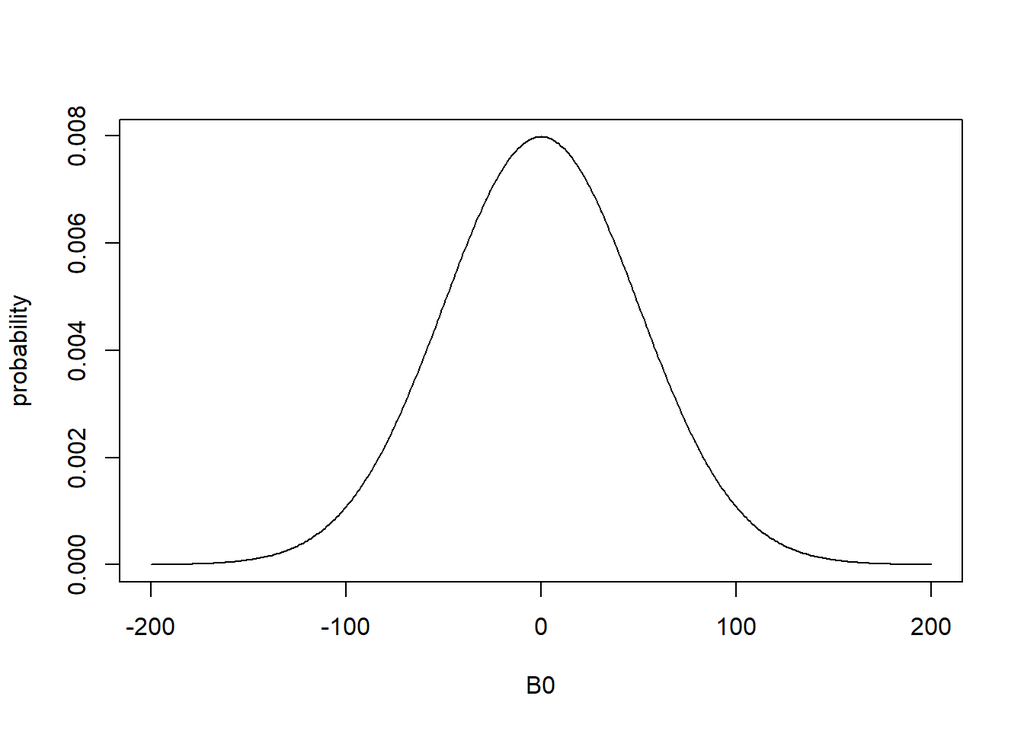

```r
# plot the probability of a range of parameter values - let's do +/-200
plot(x = -200:200, y = dnorm(-200:200, 0, 50),
     xlab = "B0", ylab = "probability",
     type = "l")
```

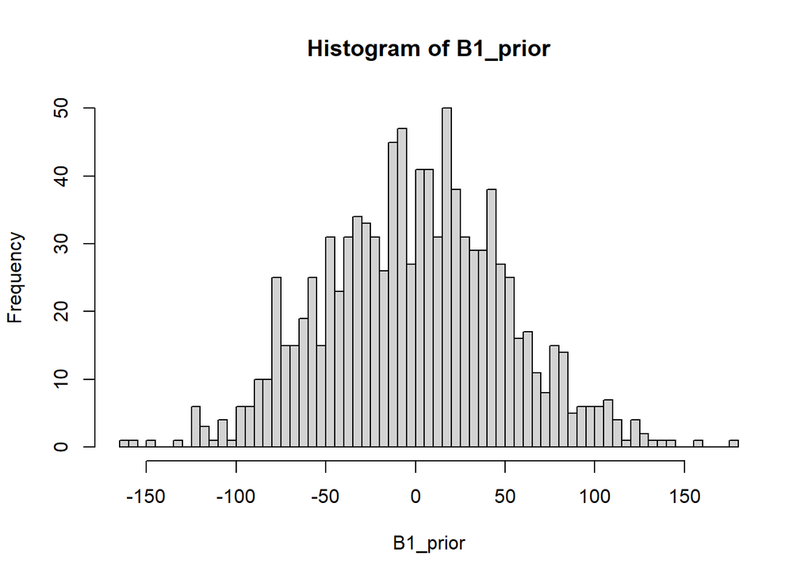

```r
# SLOPE
B1_prior = rnorm(1000, 0, 50) # draw 1000 random values from our prior
hist(B1_prior, breaks = 50)   # make a histogram of those random draws
```

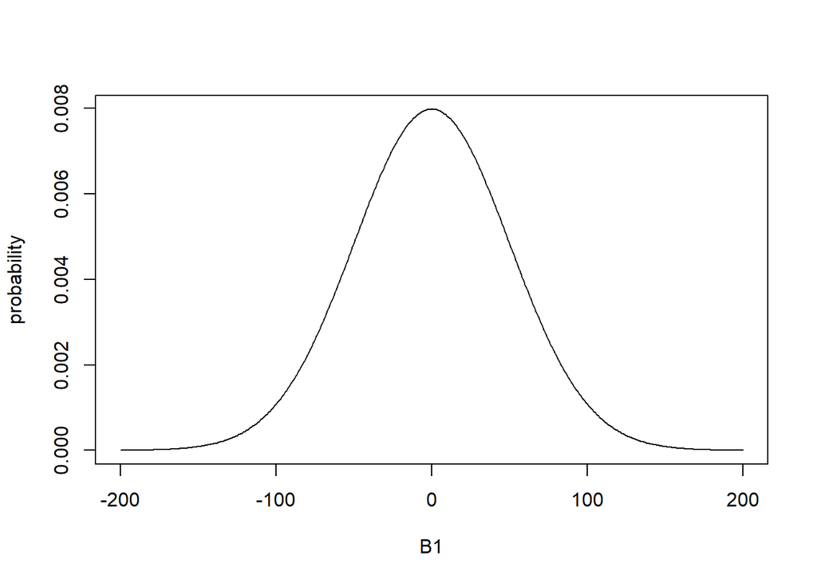

```r
# plot the probability of a range of parameter values
plot(x = -200:200, y = dnorm(-200:200, 0, 50),
     xlab = "B1", ylab = "probability",
     type = "l")
```

With a half-Cauchy prior distribution, you’ll notice that when randomly drawing from the prior, you’ll occasionally get a very large sigma value. This can make the histogram unhelpful, so I show two histograms: one with the full distribution of random draws from the prior, and one with the random draws whose value is below 200. A common alternative to the half-Cauchy is a half-normal distribution. I plot a half-normal distribution on the density plot (in red) to illustrate the similarities and differences.

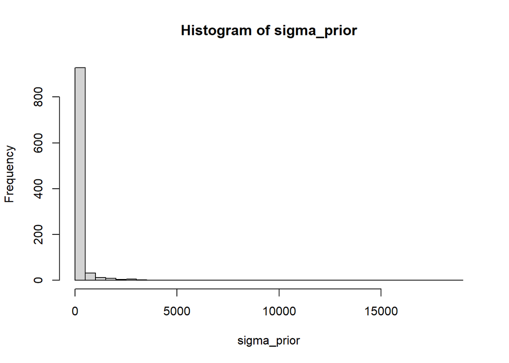

```r
# SIGMA
sigma_prior = rhcauchy(1000, 50) # draw 1000 random values from our prior
hist(sigma_prior, breaks = 50) # make a histogram of those random draws
```

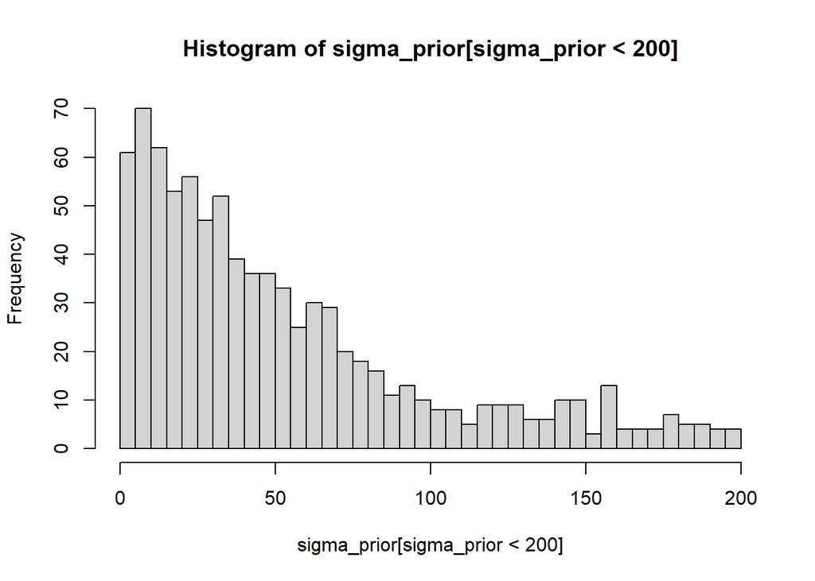

```r
hist(sigma_prior[sigma_prior<200], breaks = 50) # make a histogram of those random draws
```

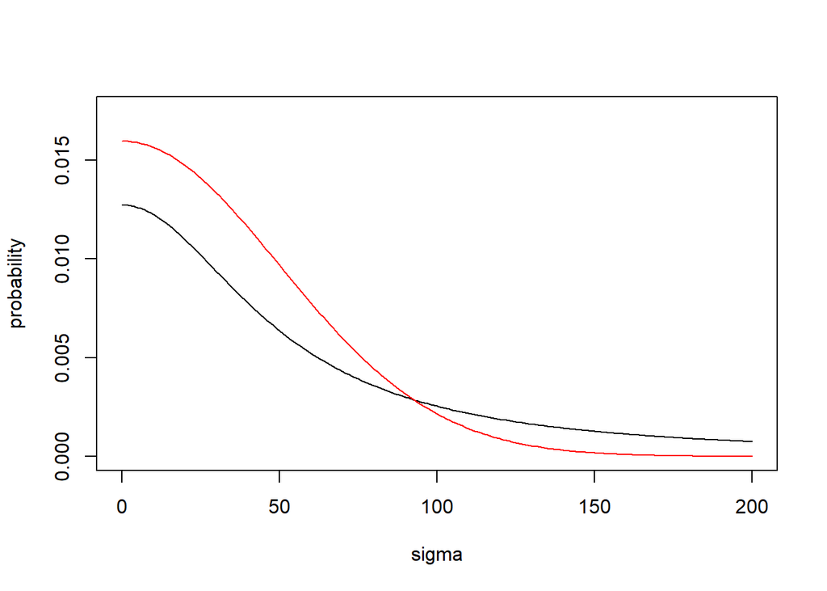

```r
# plot the probability of a range of parameter values
plot(x = 0:200, y = dhcauchy(0:200, 50),
     xlab = "sigma", ylab = "probability",
     type = "l", ylim = c(0, .0175))
lines(x = 0:200, y = dhnorm(0:200, 50), col = "red") # plot a half-normal for reference
```

### Considerations for Priors

Is the range of plausible parameter values captured by this distribution? For example, set a much more informative prior on $\beta_0$ (by lowering the SD to say 1) and think about whether your mean would fall in this range. Compare with your weakly informative prior. The first 2 plots show what a more informative prior looks like on the same x-axis scale as before. The next 2 plots show what that prior looks like on a smaller x-axis scale.

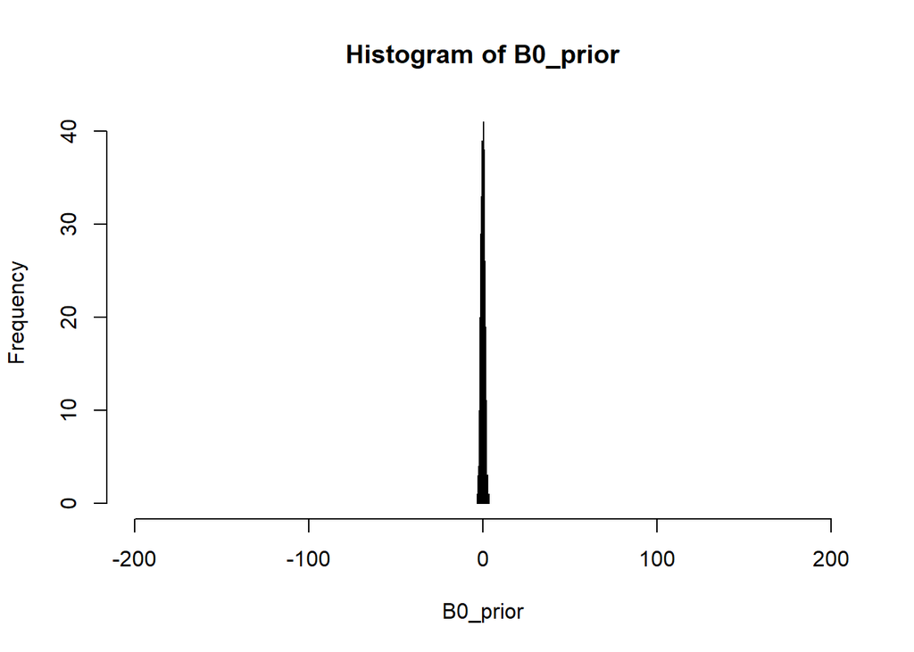

```r
B0_prior = rnorm(1000, 0, 1)
hist(B0_prior, breaks = 50, xlim = c(-200, 200))
```

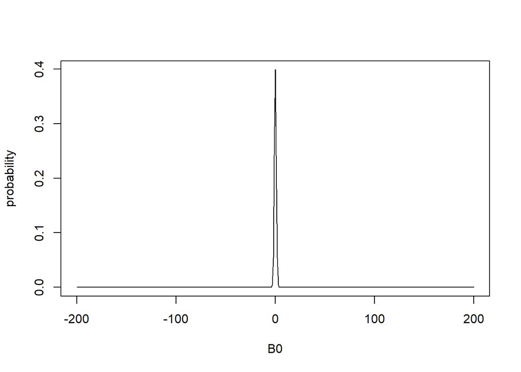

```r
plot(x = -200:200, y = dnorm(-200:200, 0, 1),
     xlab = "B0", ylab = "probability",
     type = "l")
```

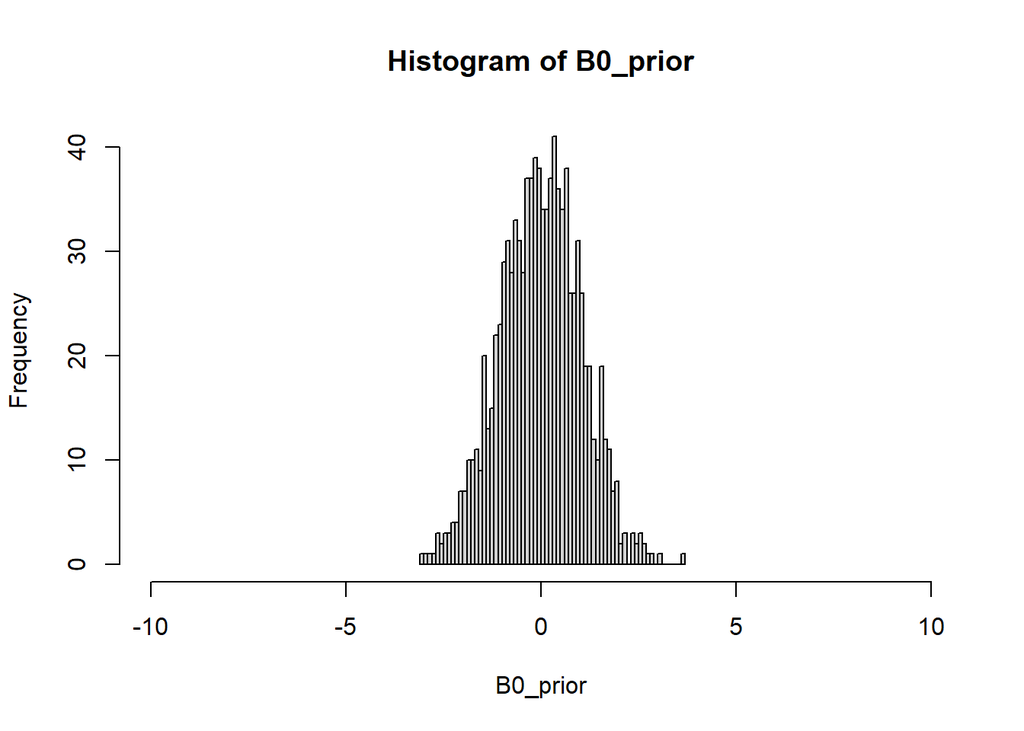

```r
hist(B0_prior, breaks = 50, xlim = c(-10, 10))
```

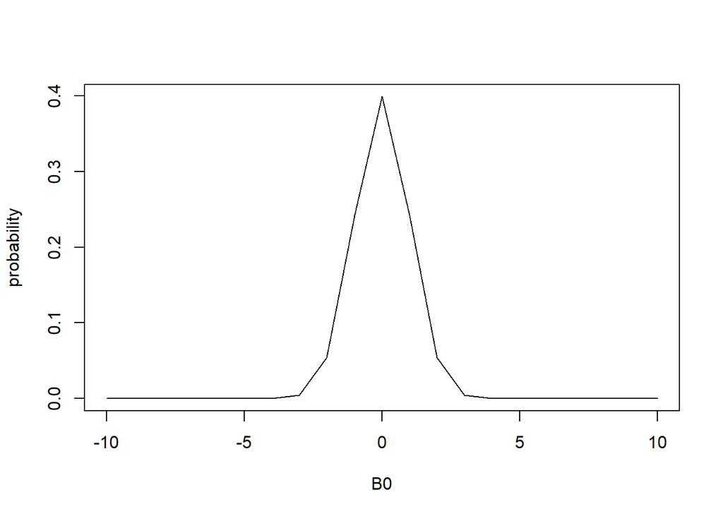

```r
plot(x = -10:10, y = dnorm(-10:10, 0, 1),
     xlab = "B0", ylab = "probability",
     type = "l")
```

Does this distribution suggest ridiculous values are plausible? Set a uniform prior for $\beta_0$ ranging from values that are functionally infinite (e.g., -10000 to +10000).

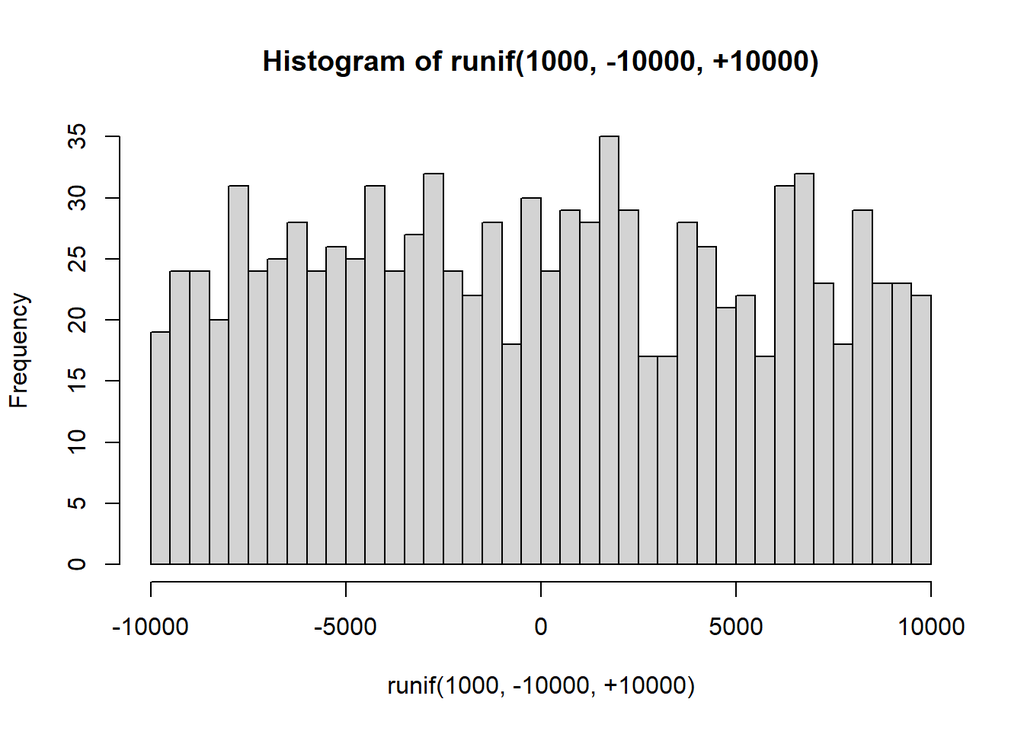

```r
hist(runif(1000, -10000, +10000), breaks = 50)
```

Are values of +/-10000 even remotely realistic? You have prior knowledge about this. Use that. I personally know that log elasticities as extreme as say +/-10 would be rare, and values as extreme as +/-100 are probably impossible given the constraints of the task (remember, tasks can only provide a range of values - e.g., SAT scores have a minimum of 400). For this data, $Normal(0,50)$ priors are very weakly informative, so stronger priors could be appropriate. Note, however, that the scaling of your variables affects how informative your priors are too. For example, if you were to recode years of fentanyl use into days without changing the prior on the slope effect (i.e., $\beta_0$), that prior now becomes extraordinarily uninformative. This is because the expected slope effect is $\sim \beta_0 / 365$. The reverse is also true (e.g., if we recoded years of fentanyl use into decades).

As with the likelihood, we’ll calculate our prior probabilities during each iteration of the MCMC; thus, we should throw this into a function to make things easier.

```r
prior_B0 = function(B0, mu = 0, sigma = 50){
  # calculate probability of the parameter
  log_prior = dnorm(x = B0,  # specify parameter
                    mean = mu,  # specify mean of our prior distribution
                    sd = sigma, # specify SD of our prior distribution
                    log = T)    # return log probability density to avoid Pbxs with small numbers
  return(log_prior)
}
```

```r
prior_B1 = function(B1, mu = 0, sigma = 50){
  # calculate probability of the parameter
  log_prior = dnorm(x = B1,   # specify parameter
                    mean = mu,  # specify mean of our prior distribution
                    sd = sigma, # specify SD of our prior distribution
                    log = T)    # return log probability density
  return(log_prior)
}
```

```r
prior_sigma = function(current_sigma, sigma = 50){
  # calculate probability of the parameter
  log_prior = dhcauchy(x = current_sigma, # specify parameter
                       sigma = sigma,     # specify SD of our prior distribution
                       log = T)           # return log probability density
  return(log_prior)
}
```

# Build the MCMC Sampler

[video not shown]

Now that we have the functions we need to calculate our likelihood and priors, we’ll use these functions in a Metropolis MCMC to estimate our regression model.

```r
###################
#### INITIAL SETUP
###################
set.seed(20240615)   # set the seed so that you can reproduce the results
n_iterations = 20000 # specify length of the MCMC chain(s)

# tuning parameters - standard deviations for Gaussian random walks to generate proposals
tuning = .5
tuning_B1 = .05 # because of the scaling of years, I needed to adjust this specific tuning parameter

# an empty dataframe to store our posterior distribution
posterior = data.frame(iteration = 1:n_iterations,
                       # posterior samples of each parameter
                       B0 = numeric(n_iterations),
                       B1 = numeric(n_iterations),
                       sigma = numeric(n_iterations),
                       # whether candidates on each iteration were accepted (1) or rejected (0)
                       accept_B0 = numeric(n_iterations),
                       accept_B1 = numeric(n_iterations),
                       accept_sigma = numeric(n_iterations))


# STEP 0: CHOOSE INITIAL VALUES - anything that's not too wild; we just need to get the MCMC started
posterior$B0[1] = runif(1, -10, 10)
posterior$B1[1] = runif(1, -10, 10)
posterior$sigma[1] = runif(1, 0, 10)
# we'll calculate the likelihood for these initial values
likelihood = calculate_likelihood(y = demand_data$log_elasticity,
                                  x = demand_data$year,
                                  B0 = posterior$B0[1],
                                  B1 = posterior$B1[1],
                                  sigma = posterior$sigma[1])


###################
#### MCMC
###################
for(i in 2:n_iterations){

  ###################
  ##### UPDATE B0
  ###################

  # STEP 1: PROPOSE CANDIDATE
  # we do this with a Gaussian random walk. That is, we generate a random number from a normal distribution.
  candidate = rnorm(n = 1,                    # generate 1 random number
                    mean = posterior$B0[i-1], # mean is the last drawn parameter estimate
                    sd = tuning)              # tuning parameter serves as SD

  # STEP 2: ESTIMATE P(ACCEPT)
  # calculate likelihood of candidate
  candidate_likelihood =
    calculate_likelihood(y = demand_data$log_elasticity,
                         x = demand_data$year,
                         # this is what we're focusing on
                         B0 = candidate,
                         # we're holding these "constant" for the moment
                         B1 = posterior$B1[i-1],
                         sigma = posterior$sigma[i-1])

  # calculate joint distributions for the current and candidate parameter estimates
  joint_current = likelihood + prior_B0(posterior$B0[i-1])
  joint_candidate = candidate_likelihood + prior_B0(candidate)

  # calculate the ratio of probabilities between the candidate and current parameter estimates
  R = exp(joint_candidate - joint_current)


  # STEP 3: ACCEPT OR REJECT
  if(R > runif(1)){ # this is a way of calculating a probability
    posterior$B0[i] = candidate       # store it in the posterior,
    posterior$accept_B0[i] = 1        # use a 1 to indicate it was accepted, and
    likelihood = candidate_likelihood # update the likelihood for use with next parameter
  }else{            # if we reject the candidate
    posterior$B0[i] = posterior$B0[i-1] # store previous value in posterior
  }


  ###################
  ##### UPDATE B1
  ###################

  # STEP 1: PROPOSE CANDIDATE
  candidate = rnorm(1,                 # generate 1 random number
                    posterior$B1[i-1], # mean is the last drawn parameter estimate
                    tuning_B1)         # tuning parameter serves as SD

  # STEP 2: ESTIMATE P(ACCEPT)
  # calculate likelihood of candidate
  candidate_likelihood =
    calculate_likelihood(y = demand_data$log_elasticity,
                         x = demand_data$year,
                         B0 = posterior$B0[i], # we use the most recent value of the posterior
                         B1 = candidate,       # this is our focus at the moment
                         sigma = posterior$sigma[i-1]) # still using this value as in previous

  # calculate joint distributions
  joint_current = likelihood + prior_B1(posterior$B1[i-1])
  joint_candidate = candidate_likelihood + prior_B1(candidate)

  # calculate acceptance probability
  R = exp(joint_candidate - joint_current)


  # STEP 3: ACCEPT OR REJECT
  if(R > runif(1)){ # this is a way of calculating a probability
    posterior$B1[i] = candidate       # store it in the posterior,
    posterior$accept_B1[i] = 1        # use a 1 to indicate it was accepted, and
    likelihood = candidate_likelihood # update the likelihood for use with next parameter
  }else{            # if we reject the candidate
    posterior$B1[i] = posterior$B1[i-1] # store previous value in posterior
  }


  ###################
  ##### UPDATE Sigma
  ###################

  # STEP 1: PROPOSE CANDIDATE
  # candidate = posterior$sigma[i-1] + runif(1,  -1, 1)
  candidate = rnorm(1,                    # generate 1 random number
                    posterior$sigma[i-1], # mean is the last drawn parameter estimate
                    tuning)               # tuning parameter serves as SD

  # THIS IS UNIQUE TO ESTIMATING SIGMA
  if(candidate < 0){ # if candidate is outside of range, keep old value
    posterior$sigma[i] = posterior$sigma[i-1]
  }else{             # otherwise, go through MCMC
    # STEP 2: ESTIMATE P(ACCEPT)
    # calculate likelihood of candidate
    candidate_likelihood =
      calculate_likelihood(y = demand_data$log_elasticity,
                           x = demand_data$year,
                           B0 = posterior$B0[i],
                           B1 = posterior$B1[i],
                           sigma = candidate)

    # calculate joint distributions
    joint_current = likelihood + prior_sigma(posterior$sigma[i-1])
    joint_candidate = candidate_likelihood + prior_sigma(candidate)

    # calculate acceptance probability
    R = exp(joint_candidate - joint_current)


    # STEP 3: ACCEPT OR REJECT
    if(R > runif(1)){ # this is a way of calculating a probability
      posterior$sigma[i] = candidate       # store it in the posterior,
      posterior$accept_sigma[i] = 1        # use a 1 to indicate it was accepted, and
      likelihood = candidate_likelihood # update the likelihood for use with next parameter
    }else{            # if we reject the candidate
      posterior$sigma[i] = posterior$sigma[i-1] # store previous value in posterior
    }
  }
}
```

# Diagnostics

Ok, now that we’ve fit our regression model using a Metropolis-Hastings MCMC, let’s process the posterior distributions that we estimated. We’ll first begin with diagnostics which focuses on examining traceplots and the acceptance rate.

## Trace-Plots

Traceplots refer to lineplots illustrating the values of a parameter (y-axis) as a function of the MCMC iteration (x-axis). Our goal here is to see if the MCMC got stuck anywhere so that we can diagnose and address any estimation problems. What we want to see is a “furry caterpillar”.

### Full Posterior

Here is the traceplot of the full posterior distribution. You will see that at the beginning of each traceplot, the parameter value jumps around quite a bit until quickly settling down into the most probable parameter space. That said, we do not want to use this kind of traceplot because those first iterations are generally not at the “equilibrium” point that we’re looking for. This is why we typically designate the first x-number of iterations as the burn-in, shown further below.

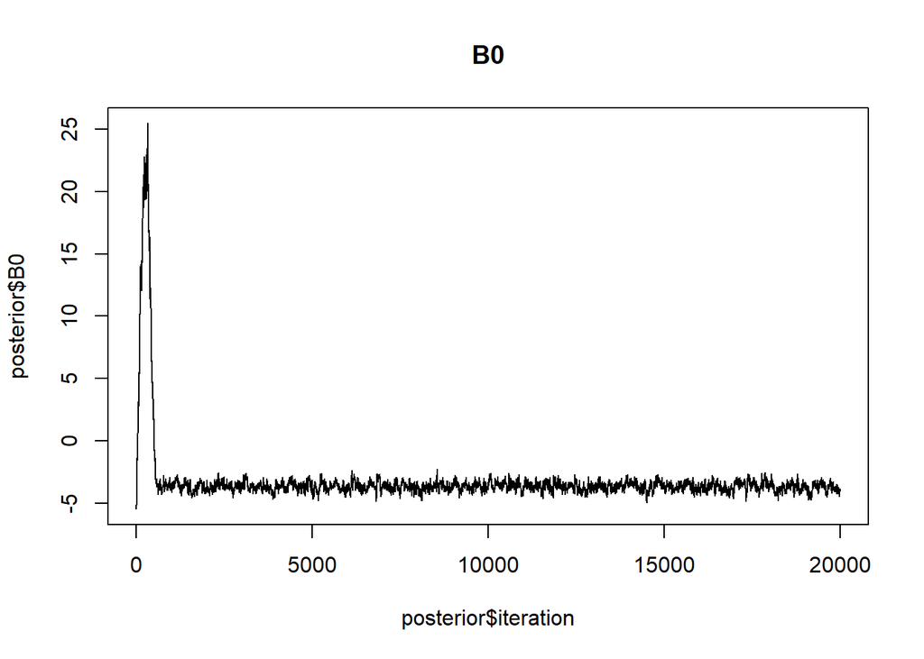

```r
# INTERCEPT
plot(x = posterior$iteration,
     y = posterior$B0,
     type = "l", main = "B0")
```

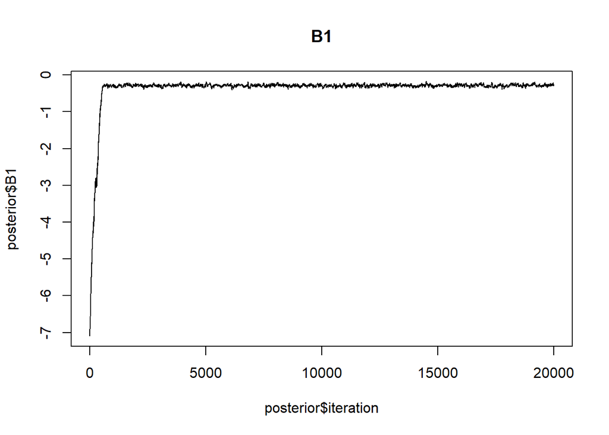

```r
# SLOPE
plot(x = posterior$iteration,
     y = posterior$B1,
     type = "l", main = "B1")
```

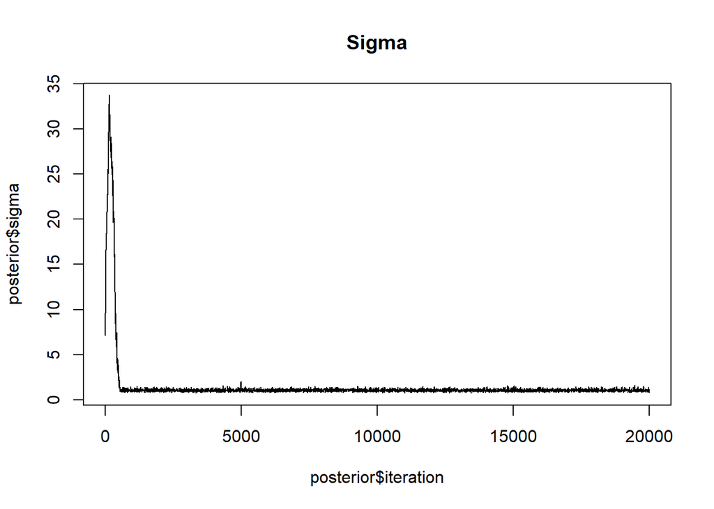

```r
# SIGMA
plot(x = posterior$iteration,
     y = posterior$sigma,
     type = "l", main = "Sigma")
```

### Posterior w/o Burn-in

I think using the first quarter as burn-in is sufficient but this is not a “hard and fast” rule. Others may feel that the first half should be used as the burn-in.

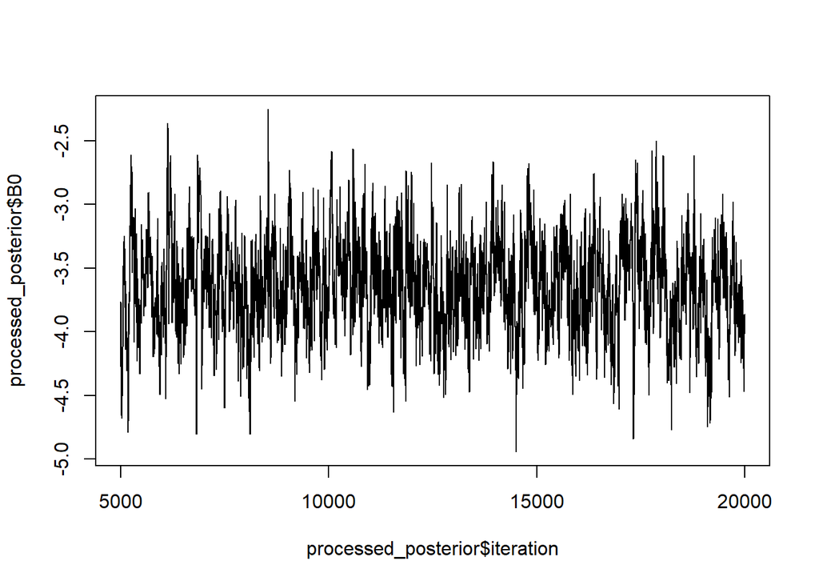

```r
burnin = 1:round(max(posterior$iteration)/4) # calculate which iterations are burn-in
processed_posterior = posterior %>%
  filter(!(iteration %in% burnin))           # filter out the burn-in


# INTERCEPT
plot(x = processed_posterior$iteration,
     y = processed_posterior$B0,
     type = "l")
```

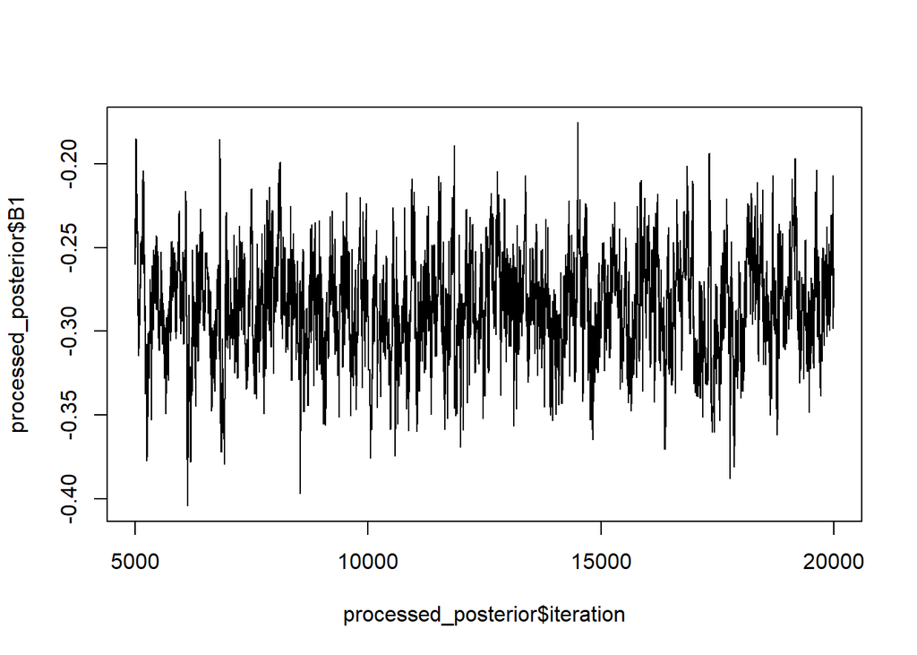

```r
# SLOPE
plot(x = processed_posterior$iteration,
     y = processed_posterior$B1,
     type = "l")
```

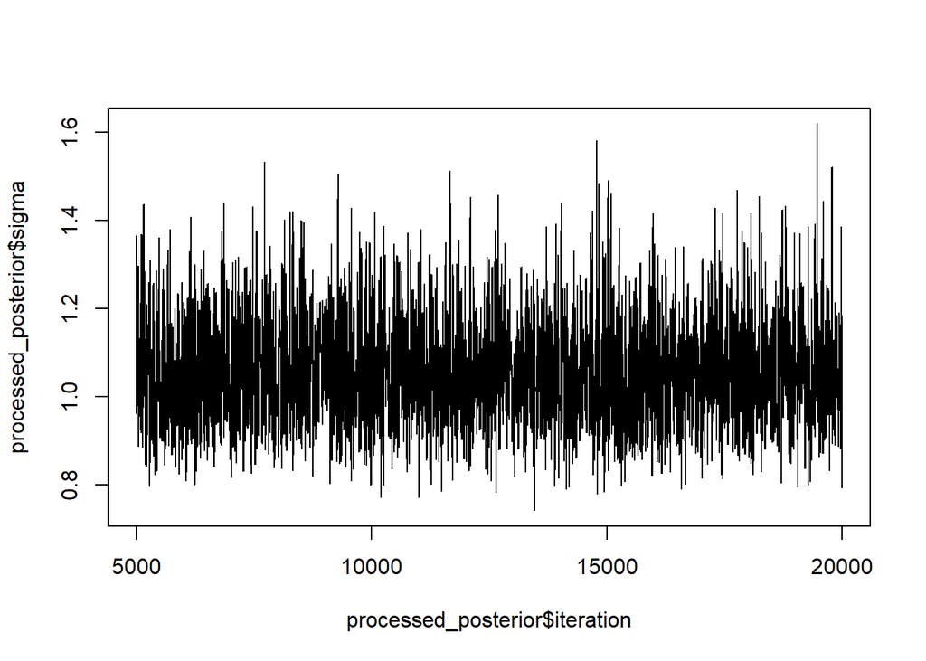

```r
# SIGMA
plot(x = processed_posterior$iteration,
     y = processed_posterior$sigma,
     type = "l")
```

… furry.

## Acceptance Rates

Now we want to calculate our acceptance rates. That is, the proportion of candidates that were accepted. This is one place to start looking if you see issues in your traceplots. In particular, if your traceplots look step-like, this might indicate that you’re rejecting too many proposed candidates. This is typically a reflection of the tuning parameter being too large for the random walk which results in large steps being taken by the random walk in generating candidates, and these large steps often result in unlikely parameter values. Remember that I specified a separate tuning parameter for the slope (i.e.,$\beta_1$). When I used the same tuning parameter for estimating all of the regression parameters, I encountered this issue with the posterior distribution for the slope. This occurred because the slope effect is fairly small; thus, when I had a large tuning parameter, this resulted in many proposals being rejected. Generally, your acceptance rate should be somewhere between 25 and 35%, but this is also not a “hard and fast” rule.

```r
processed_posterior %>%
  select(accept_B0, accept_B1, accept_sigma) %>%
  sapply(mean) %>% round(2)
```

```
##    accept_B0    accept_B1 accept_sigma
##         0.35         0.31         0.27
```

These look good.

# Summarizing Posteriors

After looking at our diagnostics for the posterior distributions, and they are “ok”, we can move on to summarizing and drawing inferences regarding our posterior distributions.

## Distribution Plots

I personally find histograms (or density plots) to be a good way to summarize and show posterior distributions. Here, I plot histograms of the posterior distributions of each parameter with solid red vertical lines for the posterior means and dashed vertical lines for the true values of the parameters (remember, I generated these data from known parameter-values).

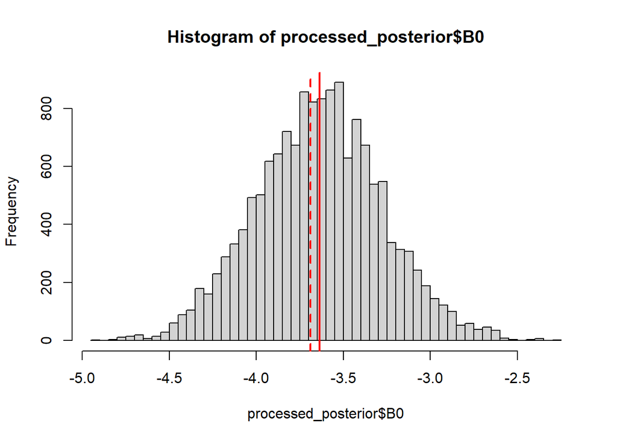

```r
# INTERCEPTS
hist(x = processed_posterior$B0, breaks = 50)                  # plot distribution
abline(v = mean(processed_posterior$B0), col = "red", lwd = 2) # vertical line at the posterior mean
abline(v = log(.025), col = "red", lty = "dashed", lwd = 2)    # vertical line at true B0
```

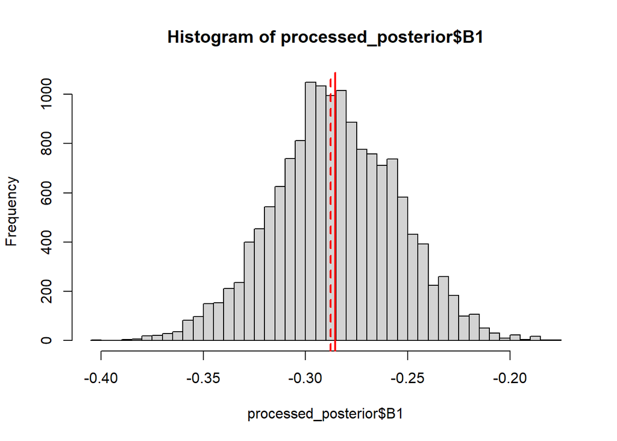

```r
# SLOPES
hist(x = processed_posterior$B1, breaks = 50)                  # plot distribution
abline(v = mean(processed_posterior$B1), col = "red", lwd = 2) # vertical line at the posterior mean
abline(v = log(.75), col = "red", lty = "dashed", lwd = 2)     # vertical line at true B1
```

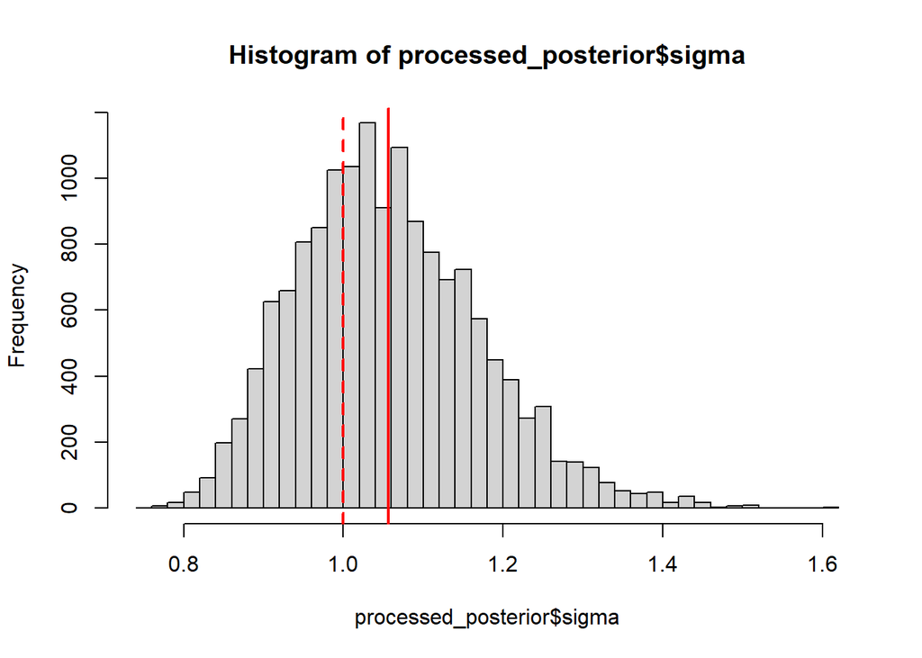

```r
# SIGMAS
hist(x = processed_posterior$sigma, breaks = 50)                  # plot distribution
abline(v = mean(processed_posterior$sigma), col = "red", lwd = 2) # vertical line at the posterior mean
abline(v = 1, col = "red", lty = "dashed", lwd = 2)     # vertical line at true B1
```

## Summary Statistics

Quantitative summary statistics are also helpful. Generally, you’ll want to show the posterior means along with some measure of spread for those posterior means. Here, I calculate 95% inner quantile ranges which can be thought of as similar to confidence intervals. Thus, we could interpret 95% IQRs that do not overlap with 0 as indicating significance. Technically speaking, we would actually want to base inference off of highest density credible intervals (HDCIs). These intervals align more closely with the interpretation we want to make; that is, HDCIs tell us the range of parameter values with some percent probability which is actually more akin to a confidence interval. IQRs and HDCIs are usually similar, so we’ll use IQRs here. There are many packages that will calculate HDCIs. I recommend the $hBayesDM$ package which has a $HDIofMCMC$ function which accepts a vector of posterior samples. Finally, it’s worth looking at how well our MCMC does compared to the more traditional frequentist approach, so there is code below for looking at that as well.

```r
# SUMMARIZE PARAMETER VALUES - Posterior Means & Inner Quantile Ranges
# B0 - true value = log(.025) = -3.688879
mean(processed_posterior$B0)
```

```
## [1] -3.637357
```

```r
quantile(processed_posterior$B0, c(.025, .975))
```

```
##      2.5%     97.5%
## -4.342413 -2.905951
```

```r
# B1 - true value = log(.75) = -0.2876821
mean(processed_posterior$B1)
```

```
## [1] -0.2854052
```

```r
quantile(processed_posterior$B1, c(.025, .975))
```

```
##       2.5%      97.5%
## -0.3470219 -0.2257164
```

```r
# Sigma - true value = 1
mean(processed_posterior$sigma)
```

```
## [1] 1.056483
```

```r
quantile(processed_posterior$sigma, c(.025, .975))
```

```
##      2.5%     97.5%
## 0.8616141 1.3114070
```

```r
# COMPARE WITH FREQUENTIST REGRESSION
lm(log_elasticity~year, demand_data) %>% summary()
```

```
##
## Call:
## lm(formula = log_elasticity ~ year, data = demand_data)
##
## Residuals:
##      Min       1Q   Median       3Q      Max
## -1.76952 -0.81883  0.08088  0.64052  2.26635
##
## Coefficients:
##             Estimate Std. Error t value Pr(>|t|)
## (Intercept) -3.61876    0.34186  -10.59 1.12e-13 ***
## year        -0.28708    0.02866  -10.02 6.35e-13 ***
## ---
## Signif. codes:  0 '***' 0.001 '**' 0.01 '*' 0.05 '.' 0.1 ' ' 1
##
## Residual standard error: 1.025 on 44 degrees of freedom
## Multiple R-squared:  0.6951, Adjusted R-squared:  0.6882
## F-statistic: 100.3 on 1 and 44 DF,  p-value: 6.352e-13
```

## Plot Regression

Finally, I like to show how well the model captures the data by plotting the regression line on top of the data. To do this, I use the posterior means for the intercept and slope coefficients. I’ve also added a line for the frequentist regression line for comparison.

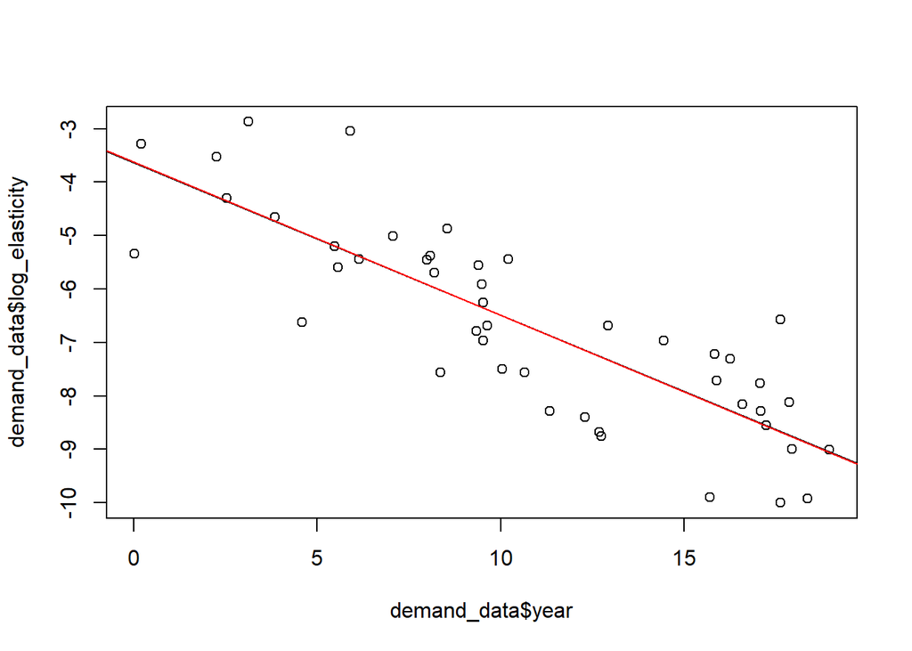

```r
plot(demand_data$year, demand_data$log_elasticity)
# ADD Regression Line
abline(coef = c(mean(processed_posterior$B0),  # intercept
                mean(processed_posterior$B1))) # slope
# COMPARE WITH FREQUENTIST REGRESSION
abline(lm(log_elasticity~year, demand_data), col = "red")
```

Note that the frequentist and Bayesian regression lines are essentially right on top of one another. I’d say our Bayesian regression does pretty well.

# What next?

Now that you know how to implement an MCMC, the next thing I recommend doing is breaking the MCMC. This is a good way to figure out how it works. One place I recommend tinkering with is the priors, particularly the standard deviations. Look at what happens when you make the SDs narrow vs. wide. Another place is messing with the tuning parameters. Set the tuning parameter for $\beta_1$ to .5 and see how that affects estimates. Do any of these changes affect the posterior mean or spread? I recommend adding another variable to the model. I specifically included an additional variable: sex. Modify the code above (or building a new sampler) to test whether sex plays a role in elasticity of demand for fentanyl. The supplemental code illustrates how I did this but doing it on your own would be a good test of your knowledge.